# Задание 1

**Retention rate** (коэффициент удержания) - одна из ключевых метрик продуктовой аналитики, характеризующая способность бизнеса удерживать пользователей в течение определенного периода времени.

Датасет, на котором тестировала корректность работы запроса:

https://disk.yandex.ru/d/2GSvpoc14FzvxA

Запрос тестировался в MySQL Workbench, в который я загрузила данные в формате csv. Оригинальная версия запроса ниже:

SELECT cohorts.first_activity_ym, cohort_lifetime, count_uid, new_users, count_uid/new_users AS rr FROM (SELECT first_activity_ym, first_activity_year, first_activity_month, cohort_lifetime, count(DISTINCT uid) AS count_uid FROM (SELECT visits.start_ts, visits.uid, visits.end_ts, first_activity_date_table.first_activity_date, MONTH(start_ts) AS activity_month, YEAR(start_ts) AS activity_year, MONTH(first_activity_date) AS first_activity_month, YEAR(first_activity_date) AS first_activity_year, EXTRACT(YEAR_MONTH FROM first_activity_date) AS first_activity_ym, EXTRACT(YEAR_MONTH FROM start_ts) AS activity_ym, 12 * (YEAR(start_ts) - YEAR(first_activity_date)) + (MONTH(start_ts) - MONTH(first_activity_date)) AS cohort_lifetime FROM new_schema.visits AS visits JOIN (SELECT uid, min(start_ts) AS first_activity_date FROM new_schema.visits GROUP BY uid) AS first_activity_date_table ON first_activity_date_table.uid = visits.uid) AS all_users_cohorts GROUP BY first_activity_ym, all_users_cohorts.cohort_lifetime) AS cohorts JOIN (SELECT EXTRACT(YEAR_MONTH FROM first_month) AS first_activity_ym, count(DISTINCT uid) AS new_users FROM (SELECT uid, min(start_ts) AS first_month FROM new_schema.visits AS visits GROUP BY uid) AS first_visit GROUP BY first_activity_ym) AS new_users ON new_users.first_activity_ym = cohorts.first_activity_ym;

Скрин части получившейся таблицы, используя которую можно сделать сводную таблицу для когортного анализа Retention Rate и визуализировать в Python с помощью heatmap:

[figure not shown]

Ссылка на таблицу, получившуюся после применения запроса:

https://disk.yandex.ru/d/OXCpe3pOw87YKA

Запрос MySQL с названием полей оригинальной таблицы из задания:

SELECT cohorts.first_activity_ym, cohort_lifetime, count_id, new_users, count_id/new_users AS rr FROM (SELECT first_activity_ym, first_activity_year, first_activity_month, cohort_lifetime, count(DISTINCT id) AS count_id FROM (SELECT visits.date, visits.id, first_activity_date_table.first_activity_date, MONTH(date) AS activity_month, YEAR(date) AS activity_year, MONTH(first_activity_date) AS first_activity_month, YEAR(first_activity_date) AS first_activity_year, EXTRACT(YEAR_MONTH FROM first_activity_date) AS first_activity_ym, EXTRACT(YEAR_MONTH FROM date) AS activity_ym, 12 * (YEAR(date) - YEAR(first_activity_date)) + (MONTH(date) - MONTH(first_activity_date)) AS cohort_lifetime FROM visits AS visits JOIN (SELECT id, min(date) AS first_activity_date FROM visits GROUP BY id) AS first_activity_date_table ON first_activity_date_table.id = visits.id) AS all_users_cohorts GROUP BY first_activity_ym, all_users_cohorts.cohort_lifetime) AS cohorts JOIN (SELECT EXTRACT(YEAR_MONTH FROM first_month) AS first_activity_ym, count(DISTINCT id) AS new_users FROM (SELECT id, min(date) AS first_month FROM visits AS visits GROUP BY id) AS first_visit GROUP BY first_activity_ym) AS new_users ON new_users.first_activity_ym = cohorts.first_activity_ym;

```python
import pandas as pd

import numpy as np

from scipy.stats import shapiro
import statsmodels.api as sm
import scipy.stats as stats

import matplotlib.pyplot as plt
import seaborn as sns
sns.set()
colors = ['#630000', '#C26565', '#A35D6A', '#D9C6A5', '#F1E3CB']
sns.palplot(sns.color_palette(colors))
```

```python
RANDOM_SEED = 0
```

```python
visits = pd.read_csv('../crazy_panda/visits_request.csv') #загрузка таблицы с Retention Rate после запроса
```

Сделаем сводную таблицу для агрегации данных, полученных после SQL запроса.

```python
retention_pivot = visits.pivot_table(index='first_activity_ym', columns='cohort_lifetime', values='rr',\
                                      aggfunc='sum')
retention_pivot.loc['Mean values', :] = retention_pivot.mean()
retention_pivot.fillna('')
```

| cohort_lifetime first_activity_ym | 0 | 1 | 2 | 3 | 4 | 5 | 6 | 7 | 8 | 9 | 10 | 11 |
| --- | --- | --- | --- | --- | --- | --- | --- | --- | --- | --- | --- | --- |
| 201706 | 1.0 | 0.0165 | 0.0165 | 0.0132 | 0.0132 | 0.0297 | 0.0231 | 0.0132 | 0.0198 | 0.0198 | 0.0099 | 0.0198 |
| 201707 | 1.0 | 0.0279 | 0.0112 | 0.0196 | 0.0223 | 0.0196 | 0.0223 | 0.0168 | 0.0112 | 0.0112 | 0.0084 |  |
| 201708 | 1.0 | 0.0163 | 0.0122 | 0.0081 | 0.0081 | 0.0122 | 0.0041 | 0.0041 | 0.0081 | 0.0041 |  |  |
| 201709 | 1.0 | 0.0044 | 0.0109 | 0.0109 | 0.0088 | 0.0066 | 0.0109 | 0.0066 | 0.0066 |  |  |  |
| 201710 | 1.0 | 0.0131 | 0.0078 | 0.0052 | 0.0078 | 0.0026 | 0.0013 | 0.0013 |  |  |  |  |
| 201711 | 1.0 | 0.0104 | 0.0046 | 0.0035 | 0.0046 | 0.0012 | 0.0023 |  |  |  |  |  |
| 201712 | 1.0 | 0.0119 | 0.006 | 0.0012 | 0.0048 | 0.0012 |  |  |  |  |  |  |
| 201801 | 1.0 | 0.0044 | 0.0058 | 0.0029 | 0.0044 |  |  |  |  |  |  |  |
| 201802 | 1.0 | 0.0097 | 0.0056 | 0.0042 |  |  |  |  |  |  |  |  |
| 201803 | 1.0 | 0.0046 | 0.0015 |  |  |  |  |  |  |  |  |  |
| 201804 | 1.0 | 0.0086 |  |  |  |  |  |  |  |  |  |  |
| 201805 | 1.0 |  |  |  |  |  |  |  |  |  |  |  |
| Mean values | 1.0 | 0.011618 | 0.00821 | 0.007644 | 0.00925 | 0.010443 | 0.010667 | 0.0084 | 0.011425 | 0.0117 | 0.00915 | 0.0198 |

Построим heatmap для лучшей визуализации данных.

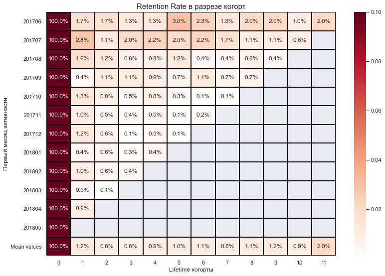

```python
plt.figure(figsize=(13,9))
plt.title('Retention Rate в разрезе когорт', size=15)
ax = sns.heatmap(retention_pivot, annot=True, fmt='.1%', linewidth=1, linecolor='black', vmax=0.1, center=0, cmap='RdGy_r')
plt.xlabel('Lifetime когорты')
plt.ylabel('Первый месяц активности')
ax.set_yticklabels(ax.get_yticklabels(), rotation=0)
plt.show()
```

# Задание 2

## Открытие файла и изучение общей информации

```python
df = pd.read_csv('../crazy_panda/task_2.csv')
```

```python
df.sample(5, random_state=RANDOM_SEED)
```

|  | user_id | ab_group | price | date |
| --- | --- | --- | --- | --- |
| 671 | 52845461 | control | 0.32 | 2020-03-07 03:17:48 |
| 877 | 71779391 | test | 0.32 | 2020-03-08 11:43:03 |
| 971 | 45457510 | test | 1.29 | 2020-03-09 04:16:05 |
| 184 | 49117573 | test | 0.32 | 2020-03-04 03:24:50 |
| 1138 | 47079673 | test | 10.00 | 2020-03-09 16:49:42 |

```python
df.info()
```

```
<class 'pandas.core.frame.DataFrame'>
RangeIndex: 1139 entries, 0 to 1138
Data columns (total 4 columns):
 #   Column    Non-Null Count  Dtype
---  ------    --------------  -----
 0   user_id   1139 non-null   int64
 1   ab_group  1139 non-null   object
 2   price     1139 non-null   float64
 3   date      1139 non-null   object
dtypes: float64(1), int64(1), object(2)
memory usage: 35.7+ KB
```

```python
display(df.describe().T)
display(df.describe(include=object).T)
```

|  | count | mean | std | min | 25% | 50% | 75% | max |
| --- | --- | --- | --- | --- | --- | --- | --- | --- |
| user_id | 1139.0 | 6.437833e+07 | 2.113881e+07 | 45457510.00 | 49036153.50 | 57499958.00 | 68672731.0 | 1.157273e+08 |
| price | 1139.0 | 3.243521e+00 | 7.367229e+00 | 0.01 | 0.65 | 1.75 | 2.6 | 1.752700e+02 |

|  | count | unique | top | freq |
| --- | --- | --- | --- | --- |
| ab_group | 1139 | 2 | test | 700 |
| date | 1139 | 1137 | 2020-03-07 00:13:23 | 2 |

В датасете присутствуют 2 группы A/B теста - контрольная и тестовая, даны id пользователей, цена совершенной покупки по каждому пользователю и даты совершения покупки. Всего в данных 1139 строк и 4 столбца. Видим, что столбец `date` необходимо перевести в формат даты, а в остальных столбцах тип данных приведен верно, но можно понизить разрядность и таким образом оптимизировать работу кода.

```python
df['date'] = pd.to_datetime(df['date'], format='%Y-%m-%d')
df['user_id'] = pd.to_numeric(df['user_id'], downcast='signed')
df['price'] = pd.to_numeric(df['price'], downcast='float')
```

```python
df.info()
```

```
<class 'pandas.core.frame.DataFrame'>
RangeIndex: 1139 entries, 0 to 1138
Data columns (total 4 columns):
 #   Column    Non-Null Count  Dtype
---  ------    --------------  -----
 0   user_id   1139 non-null   int32
 1   ab_group  1139 non-null   object
 2   price     1139 non-null   float32
 3   date      1139 non-null   datetime64[ns]
dtypes: datetime64[ns](1), float32(1), int32(1), object(1)
memory usage: 26.8+ KB
```

```python
print(f'Количество дубликатов в датасете: {df.duplicated().sum()}')
```

```
Количество дубликатов в датасете: 0
```

### Выводы

- В датасете присутствуют 2 группы A/B теста - контрольная и тестовая, даны id пользователей, цена совершенной покупки по каждому пользователю и даты совершения покупки.
- Всего в данных 1139 строк и 4 столбца.
- Столбец date перевели в формат даты, а также понизили разрядность типов данных и таким образом оптимизировали работу кода.
- Дубликаты отстутствуют.

## Исследовательский анализ данных

Проверим есть ли в таблице пользователи, попавшие и в группу A, и в группу B.

```python
users_counter = df.groupby('user_id')['ab_group'].nunique()
users_both_group = users_counter[users_counter>1].index
print(f'Пользователи, попавшие в обе группы: {len(users_both_group)}')
```

```
Пользователи, попавшие в обе группы: 31
```

Таких пользователей 31 во всем датасете. Удалим их из наших данных, поскольку они будут искажать проведение А/Б теста.

```python
df = df[~df['user_id'].isin(users_both_group)]
```

```python
print('Минимальная дата: ', df['date'].min())
print('Максимальная дата: ', df['date'].max())
```

```
Минимальная дата:  2020-03-02 17:08:50
Максимальная дата:  2020-03-09 16:42:01
```

Выходит, что мы располагаем данными за недельный период: 02.03.2020 -09.03.2020.

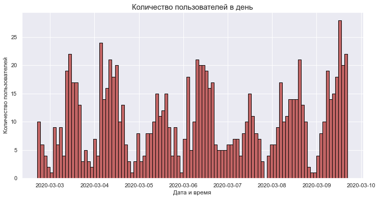

```python
plt.figure(figsize = (12,6))
plt.title('Количество пользователей в день', size = 15)
plt.hist(df['date'], bins = 100, color=colors[1], edgecolor='black' )
plt.xlabel('Дата и время')
plt.ylabel('Количество пользователей')
plt.xticks(rotation=0)
plt.show()
```

По распределению видим, что у нас полные данные за рассматриваемый период времени. Но период проведения А/Б теста совпадает с праздником - 8 марта, что в целом может привести к искажению результатов теста.

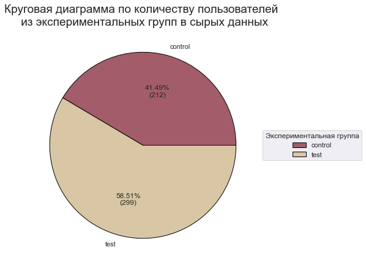

```python
group_pie = df.groupby('ab_group').agg({'user_id':'nunique'})\
.rename(columns={'user_id':'count_users'}).reset_index()

def my_fmt(x):
    return '{:.2f}%\n({:.0f})'.format(x, total*x/100)
total = group_pie['count_users'].sum()

plt.figure(figsize=(7,7))
plt.title('Круговая диаграмма по количеству пользователей \n из экспериментальных групп в сырых данных', size = 19)
plt.pie(group_pie['count_users'], autopct = my_fmt, labels = group_pie['ab_group'],
        wedgeprops={'edgecolor': 'black'}, colors=colors[2:])
plt.legend(title = 'Экспериментальная группа',
          loc = 'center left',
             bbox_to_anchor=(1, 0, 0.5, 1))
plt.show()
```

```python
print(f'Общее количество пользователей, участвующих в А/Б тесте: {total}')
```

```
Общее количество пользователей, участвующих в А/Б тесте: 511
```

Есть небольшой перекос в количестве пользователей, участвующих в тесте - количество пользователей в контрольной группе - 212 (41.49%), количество пользователей в тестовой группе - 299 (58.51%). В ТЗ звучит информация, что всего в тесте участвовало ровно по 1000 пользователей в каждой группе. У нас не набралось такого количества пользователей - общее количество пользователей, участвующих в А/Б тесте по нашим расчетам - 511.

### Выводы

- В датасете присутствуют пользователи, попавшие и в группу A, и в группу B. Таких пользователей 31 во всем датасете. Мы их удалили из наших данных, поскольку они будут искажать проведение А/Б теста.
- Мы располагаем данными за недельный период: 02.03.2020 -09.03.2020. По распределению видим, что у нас полные данные за рассматриваемый период времени. Но период проведения А/Б теста совпадает с праздником - 8 марта, что в целом может привести к искажению результатов теста.
- Есть небольшой перекос в количестве пользователей, участвующих в тесте - количество пользователей в контрольной группе - 212 (41.49%), количество пользователей в тестовой группе - 299 (58.51%). В ТЗ звучит информация, что всего в тесте участвовало ровно по 1000 пользователей в каждой группе. У нас не набралось такого количества пользователей - общее количество пользователей, участвующих в А/Б тесте по нашим расчетам - 511.

## Анализ куммулятивной выручки и среднего чека по группам на сырых данных

```python
df['date'] =df['date'].astype('datetime64[D]')
```

Создадим массив с уникальными парами значений дат и групп теста.

```python
datesGroups = df[['date', 'ab_group']].drop_duplicates()
```

Получим агрегированные кумулятивные данные по дням о суммарной выручке и количестве покупателей.

```python
cumulativeData = datesGroups.apply(lambda x: df[np.logical_and(df['date'] <= x['date'],
                                                                    df['ab_group'] == x['ab_group'])]\
                                    .agg({'date':'max', 'ab_group':'max',
                                         'user_id':pd.Series.nunique, 'price':'sum'}), axis=1)\
                                    .sort_values(by=['date', 'ab_group'])
cumulativeData.rename(columns={'user_id':'buyers', 'price':'revenue'}, inplace=True)
```

Разделим данные на кумулятивной выручки по двум группам.

```python
cumulativeRevenueA = cumulativeData[cumulativeData['ab_group'] == 'control'][['date', 'revenue', 'buyers']]
cumulativeRevenueB = cumulativeData[cumulativeData['ab_group'] == 'test'][['date', 'revenue', 'buyers']]
```

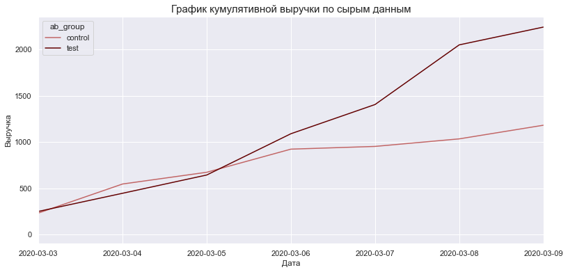

```python
plt.figure(figsize = (13,6))
plt.title('График кумулятивной выручки по сырым данным',size=15)
sns.lineplot(data=cumulativeData, x='date', y='revenue', hue='ab_group', palette=[colors[1], colors[0]])
plt.xlabel('Дата', size=12)
plt.ylabel('Выручка', size=12)
plt.xticks(rotation=0)
plt.xlim(np.datetime64('2020-03-03 00:00:00'), np.datetime64('2020-03-09 00:00:00'))
plt.show()
```

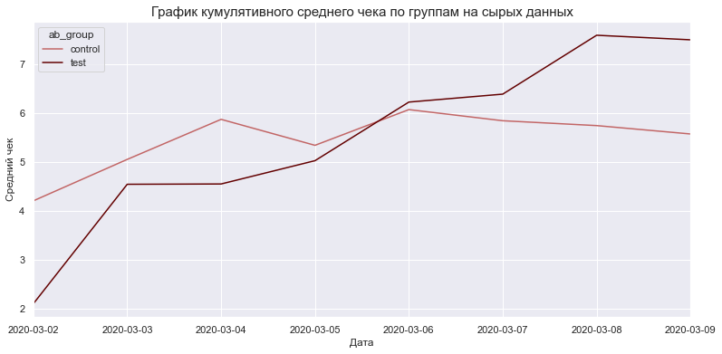

```python
plt.figure(figsize=(13,6))
plt.title('График кумулятивного среднего чека по группам на сырых данных',size=15)
sns.lineplot(data=cumulativeData, x='date',
             y=cumulativeData['revenue']/cumulativeData['buyers'],
             hue='ab_group', palette=[colors[1], colors[0]])
plt.xlabel('Дата', size=12)
plt.ylabel('Cредний чек', size=12)
plt.xlim(np.datetime64('2020-03-02 00:00:00'), np.datetime64('2020-03-09 00:00:00'))
plt.xticks(rotation=0)
plt.show()
```

По графику видим, что в начале теста кумулятивный средний чек по контрольной группе был выше, чем по тестовой, но в середине теста тестовая группа начала показывать лучшие результаты по сравнению с контрольной.

```python
mergedCumulativeRevenue = cumulativeRevenueA.merge(cumulativeRevenueB, left_on='date', right_on='date',
                                                   how='left', suffixes=['A', 'B'])
```

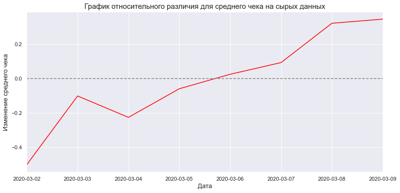

```python
#Построим график относительного различия для среднего чека
plt.figure(figsize=(13, 6))
plt.title('График относительного различия для среднего чека на сырых данных', size=15)
sns.lineplot(data=mergedCumulativeRevenue,
             x=mergedCumulativeRevenue['date'],
             y=(mergedCumulativeRevenue['revenueB']/mergedCumulativeRevenue['buyersB'])
             /(mergedCumulativeRevenue['revenueA']/mergedCumulativeRevenue['buyersA'])-1,
             color='red')
plt.xticks(rotation=0)
plt.xlabel('Дата', size=13)
plt.ylabel('Изменение среднего чека', size=13)
plt.axhline(y=0, color='grey', linestyle='--')
plt.xlim(np.datetime64('2020-03-02 00:00:00'), np.datetime64('2020-03-09 00:00:00'))
plt.show()
```

По графику относительного различия для среднего чека мы также видим, что в середине периода тестовая группа начала обгонять контрольную по величине среднего чека, о чем свидетельствуют значения графика выше нуля начиная с 6 марта.

## Анализ выбросов в данных

Проанализируем данные и проверим есть ли в них выбросы, которые смогут исказить анализ А/Б теста.

```python
orders_data = df.groupby('user_id').agg({'user_id':'count', 'price':'sum'})\
.rename(columns={'user_id':'count_orders', 'price':'revenue'}).reset_index()
```

```python
id_group = df[['user_id', 'ab_group']].drop_duplicates()
orders_data = orders_data.merge(id_group, on='user_id', how='inner')
```

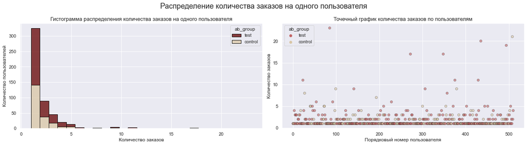

```python
fig, axs = plt.subplots(1,2, figsize=(18,5))
plt.suptitle('Распределение количества заказов на одного пользователя', size=18)

#Построение гистограммы
sns.histplot(data=orders_data, x='count_orders', multiple="stack", bins=25,
             edgecolor='black', hue='ab_group', palette=[colors[0], colors[3]], ax=axs[0])
axs[0].set_title('Гистограмма распределения количества заказов на одного пользователя', size=13)
axs[0].set_xlabel('Количество заказов')
axs[0].set_ylabel('Количество пользователей')

#Построение точечного графика
x_values1 = pd.Series(range(0,len(orders_data)))
sns.scatterplot(x=x_values1, y=orders_data['count_orders'], edgecolor='black', hue=orders_data['ab_group'],
               palette=[colors[1], colors[3]], alpha=0.6)
axs[1].set_title('Точечный график количества заказов по пользователям', size=13)
axs[1].set_xlabel('Порядковый номер пользователя')
axs[1].set_ylabel('Количество заказов')

plt.tight_layout(pad=1)

plt.show()
```

```python
print('90, 95 и 99 перцентили:', np.percentile(orders_data['count_orders'], [90, 95, 99]))
```

```
90, 95 и 99 перцентили: [ 4.   5.  16.4]
```

Видим, что по количеству заказов в контрольной и тестовой группе наблюдаются выбросы. Больше всего пользователей совершили до 5 покупок. Значения выше 16 покупок можно назвать выбросами.

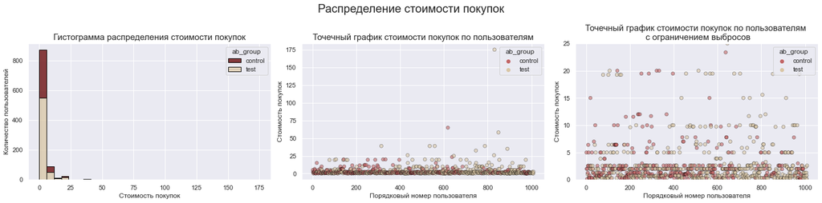

```python
fig, (ax1, ax2, ax3) = plt.subplots(
    nrows=1, ncols=3,
    figsize=(20, 5)
)

plt.suptitle('Распределение стоимости покупок', size=20)

#Построение гистограммы
sns.histplot(data=df, x='price', multiple="stack", bins=30,
             edgecolor='black', hue='ab_group', palette=[colors[0], colors[3]], ax=ax1)
ax1.set_title('Гистограмма распределения стоимости покупок', size=15)
ax1.set_xlabel('Стоимость покупок')
ax1.set_ylabel('Количество пользователей')


#Построение точечного графика
x_values = pd.Series(range(0,len(df['price'])))
sns.scatterplot(x=x_values, y=df['price'], edgecolor='black', hue=df['ab_group'],
               palette=[colors[1], colors[3]], alpha=0.6, ax=ax2)
ax2.set_title('Точечный график стоимости покупок по пользователям', size=15)
ax2.set_xlabel('Порядковый номер пользователя')
ax2.set_ylabel('Стоимость покупок')

#Построение точечного графика с ограничением выбросов
sns.scatterplot(x=x_values, y=df['price'], edgecolor='black', hue=df['ab_group'],
               palette=[colors[1], colors[3]], alpha=0.6, ax=ax3)
ax3.set_title('Точечный график стоимости покупок по пользователям \n c ограничением выбросов', size=15)
ax3.set_xlabel('Порядковый номер пользователя')
ax3.set_ylabel('Стоимость покупок')
ax3.set_ylim(0, 25)

plt.tight_layout(pad=1)

plt.show()
```

```python
print('90, 95 и 99 перцентили:', np.percentile(df['price'], [90, 95, 99]))
```

```
90, 95 и 99 перцентили: [ 7.78999996 11.68000031 25.95279909]
```

Больше всего пользователей совершили покупки на сумму до 11 у.е. Значения цены свыше 25 у.е. являются выбросами.

### Выводы

- По количеству заказов в контрольной и тестовой группе наблюдаются выбросы. Больше всего пользователей совершили до 5 покупок. Значения выше 16 покупок можно назвать выбросами.
- Больше всего пользователей совершили покупки на сумму до 11 у.е. Значения цены свыше 25 у.е. являются выбросами.

## Тестирование гипотез на сырых данных

Разделим наши данные по среднему чеку на 2 выборки - по контрольной и тестовой группе.

```python
control = df[df['ab_group']=='control']['price']
test = df[df['ab_group']=='test']['price']
```

Построим графики для визуального анализа распределения в наших выборках.

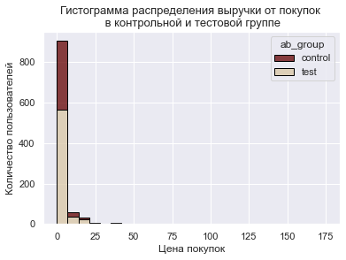

```python
sns.histplot(data=df, x="price", hue="ab_group", multiple="stack", bins=25, palette=[colors[0], colors[3]],
             edgecolor='black')
plt.title('Гистограмма распределения выручки от покупок \n в контрольной и тестовой группе', size=13)
plt.xlabel('Цена покупок')
plt.ylabel('Количество пользователей')
plt.show()
```

Визуально видим, что распределение далеко от нормального в контрольной и тестовой выборке, но для надежности построим также график квантиль-квантиль плот.

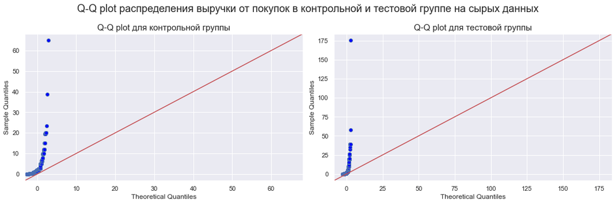

```python
fig, axs = plt.subplots(1,2, figsize=(15,5))
plt.suptitle('Q-Q plot распределения выручки от покупок в контрольной и тестовой группе на сырых данных', size=18)

sm.qqplot(control, line='45', ax=axs[0])
axs[0].set_title('Q-Q plot для контрольной группы', size=15)

sm.qqplot(test, line='45', ax=axs[1])
axs[1].set_title('Q-Q plot для тестовой группы', size=15)

plt.tight_layout(pad=1)
plt.show()
```

Из данных графиков также видим, что распределения в наших выборках отличается от нормального. Дополнительно проверим наше утверждение, используя тест Шапиро-Уилка.

Сформулируем нулевую и альтернативную гипотезы: **Н0** - выборка среднего чека в экспериментальной группе распределена нормально, **Н1** - распределение в выборке среднего чека отличается от нормального, **alpha** - критический уровень статистической значимости примем равным 5%

```python
alpha = 0.05
shapiro_control = shapiro(control)
print('**Результат по контрольной группе:**')
print(shapiro_control)
if shapiro_control.pvalue < alpha:
    print('Отвергаем нулевую гипотезу, распределение отлично от нормального')
else:
     print('Не отвергаем нулевую гипотезу, данные распределены нормально')

shapiro_test = shapiro(test)
print()
print('**Результат по тестовой группе:**')
print(shapiro_test)
if shapiro_test.pvalue < alpha:
    print('Отвергаем нулевую гипотезу, распределение отлично от нормального')
else:
     print('Не отвергаем нулевую гипотезу, данные распределены нормально')
```

```
**Результат по контрольной группе:**
ShapiroResult(statistic=0.4803200364112854, pvalue=1.442003017787892e-31)
Отвергаем нулевую гипотезу, распределение отлично от нормального

**Результат по тестовой группе:**
ShapiroResult(statistic=0.30515843629837036, pvalue=1.6955711418330287e-43)
Отвергаем нулевую гипотезу, распределение отлично от нормального
```

Нулевая гипотеза отвергается, что значит распределение в обеих выборках отлично от нормального, и следовательно будем использовать непараметрический критерий Манна-Уитни для тестирования гипотезы о наличии значимого различия в среднем чеке контрольной и тестовой группах.

Сформулируем нулевую и альтернативную гипотезы: **Н0** - значимые различия среднего чека в контрольной и тестовой группе отсутствуют, **Н1** - существуют значимые различия среднего чека в контрольной и тестовой группе, **alpha** - критический уровень статистической значимости примем равным 5%

```python
print('p-value критерия Манна-Уитни: {0:.3f}'.format(stats.mannwhitneyu(control, test, alternative='two-sided')[1]))
alpha=0.05
if stats.mannwhitneyu(control, test, alternative='two-sided')[1] < alpha:
    print('Отвергаем нулевую гипотезу, существуют значимые различия среднего чека в экспериментальных группах')
else:
    print('Не удалось отвергнуть нулевую гипотезу, значимые различия среднего чека в экспериментальных группах отсутствуют')
print('Относительные различия в среднем чеке между группами: {0:.3f}'.format(test.mean()/control.mean()-1))
```

```
p-value критерия Манна-Уитни: 0.014
Отвергаем нулевую гипотезу, существуют значимые различия среднего чека в экспериментальных группах
Относительные различия в среднем чеке между группами: 0.116
```

По "сырым" данным с выбросами получили, что нулевая гипотеза отвергается, существуют значимые различия среднего чека в экспериментальных группах. Средний чек тестовой группы значительно выше среднего чека контрольной группы, о чем свидетельствуют расчеты относительных различий в среднем чеке между группами - разница составляет 11.6%

Теперь проведем тестирование гипотезы о наличии значимых различий в средней выручки на пользователя по сырым данным. Разделим данные на 2 выборки средней выручки - контрольную и тестовую.

```python
control_revenue = orders_data[orders_data['ab_group'] == 'control']['revenue']
test_revenue = orders_data[orders_data['ab_group'] == 'test']['revenue']
```

Построим Q-Q плоты для визуализации распределения.

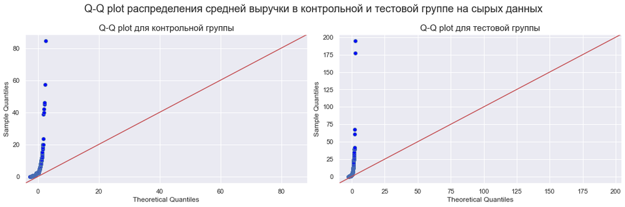

```python
fig, axs = plt.subplots(1,2, figsize=(15,5))
plt.suptitle('Q-Q plot распределения средней выручки в контрольной и тестовой группе на сырых данных', size=18)

sm.qqplot(control_revenue, line='45', ax=axs[0])
axs[0].set_title('Q-Q plot для контрольной группы', size=15)

sm.qqplot(test_revenue, line='45', ax=axs[1])
axs[1].set_title('Q-Q plot для тестовой группы', size=15)

plt.tight_layout(pad=1)
plt.show()
```

Распределение по выборкам отлично от нормального, проверим дополнительно это утверждение проведя тест Шапиро-Уилка.

Сформулируем нулевую и альтернативную гипотезы: **Н0** - средняя выручка на пользователя в выборке в экспериментальной группе распределена нормально, **Н1** - распределение средней выручки на пользователя в выборке отличается от нормального, **alpha** - критический уровень статистической значимости примем равным 5%

```python
alpha = 0.05
shapiro_control = shapiro(control_revenue)
print('**Результат по контрольной группе:**')
print(shapiro_control)
if shapiro_control.pvalue < alpha:
    print('Отвергаем нулевую гипотезу, распределение отлично от нормального')
else:
     print('Не отвергаем нулевую гипотезу, данные распределены нормально')

shapiro_test = shapiro(test_revenue)
print()
print('**Результат по тестовой группе:**')
print(shapiro_test)
if shapiro_test.pvalue < alpha:
    print('Отвергаем нулевую гипотезу, распределение отлично от нормального')
else:
     print('Не отвергаем нулевую гипотезу, данные распределены нормально')
```

```
**Результат по контрольной группе:**
ShapiroResult(statistic=0.48589664697647095, pvalue=1.992720233434357e-24)
Отвергаем нулевую гипотезу, распределение отлично от нормального

**Результат по тестовой группе:**
ShapiroResult(statistic=0.3447142243385315, pvalue=2.4741132713338837e-31)
Отвергаем нулевую гипотезу, распределение отлично от нормального
```

Гипотеза о том, что выборка распределена нормально отверглась в случае тестовой и контрольной группы, соответственно используем Тест Манна-Уитни для проверки гипотезы о том, является ли разница в средней выручке между группами статистически значимой.

Сформулируем нулевую и альтернативную гипотезы: **Н0** - значимые различия в средней выручке в контрольной и тестовой группе отсутствуют, **Н1** - существуют значимые различия в средней выручке в контрольной и тестовой группе, **alpha** - критический уровень статистической значимости примем равным 5%

```python
print('p-value критерия Манна-Уитни: {0:.3f}'.format(stats.mannwhitneyu(control_revenue, test_revenue,
                                                                        alternative='two-sided')[1]))
alpha=0.05
if stats.mannwhitneyu(control_revenue, test_revenue, alternative='two-sided')[1] < alpha:
    print('Отвергаем нулевую гипотезу, существуют значимые различия в средней выручке в экспериментальных группах')
else:
    print('Не удалось отвергнуть нулевую гипотезу, значимые различия в средней выручке в экспериментальных группах отсутствуют')
print('Относительные различия в средней выручке между группами: {0:.3f}'\
      .format(test_revenue.mean()/control_revenue.mean()-1))
print('Относительные различия в суммарной выручке между группами: {0:.3f}'\
      .format(test_revenue.sum()/control_revenue.sum()-1))
```

```
p-value критерия Манна-Уитни: 0.125
Не удалось отвергнуть нулевую гипотезу, значимые различия в средней выручке в экспериментальных группах отсутствуют
Относительные различия в средней выручке между группами: 0.346
Относительные различия в суммарной выручке между группами: 0.898
```

Нам не удалось отвергнуть нулевую гипотезу, значимые различия в средней выручке в экспериментальных группах отсутствуют. При этом при расчете относительных различий в средней выручке между группами получили, что тестовая группа показала результаты лучше, чем контрольная - выручка выше на 34.6%. При этом разница между сегментами в суммарной выручке составляет 89.8%

### Выводы

- Разделили наши данные на 2 выборки - по контрольной и тестовой группе.
- Построили графики для визуального анализа распределения в наших выборках. В результате увидили, что распределение далеко от нормального в контрольной и тестовой выборке
- Дополнительно проверили наше утверждение, используя тест Шапиро-Уилка. После проведения теста получили что гипотеза H0 отвергается (Н0 - выборка среднего чека в экспериментальной группе распределена нормально), поэтому далее использовали непараметрический критерий Манна-Уитни для тестирования гипотезы о наличии значимого различия в среднем чеке контрольной и тестовой группах.
- По "сырым" данным с выбросами получили, что нулевая гипотеза отвергается, существуют значимые различия среднего чека в экспериментальных группах. Средний чек тестовой группы значительно выше среднего чека контрольной группы, о чем свидетельствуют расчеты относительных различий в среднем чеке между группами - разница составляет 11.6%
- Провели тестирование гипотезы о наличии значимых различий в средней выручке на пользователя по сырым данным. Разделили данные на 2 выборки средней выручки - контрольную и тестовую. Построили Q-Q плоты для визуализации распределения. Распределение по выборкам отлично от нормального, проверили дополнительно это утверждение проведя тест Шапиро-Уилка. Гипотеза о том, что выборка распределена нормально отверглась в случае тестовой и контрольной группы, соответственно использовали Тест Манна-Уитни для проверки гипотезы о том, является ли разница в средней выручке между группами статистически значимой.
- Нам не удалось отвергнуть нулевую гипотезу, значимые различия в средней выручке в экспериментальных группах отсутствуют. При этом при расчете относительных различий в средней выручке между группами получили, что тестовая группа показала результаты лучше, чем контрольная - выручка выше на 34.6%. При этом разница между сегментами в суммарной выручке составляет 89.8%

## Анализ куммулятивной выручки и среднего чека по группам на очищенных данных

Отфильтруем значения выбросов, которые мы получили, рассчитав 99 квантиль по количеству покупок и сумме выручки от покупок и построим графики по очищенным данным.

```python
df_filtered = df[~df['user_id']\
                 .isin(orders_data[orders_data['count_orders']>=np.percentile(orders_data['count_orders'],
                                                                              [90, 95, 99])[2]]['user_id'])]
df_filtered = df_filtered[df_filtered['price'] <= np.percentile(df['price'], [90, 95, 99])[2]]
```

```python
print('Количество аномальных пользователей: {:.0f}'.format(df['user_id'].nunique()-df_filtered['user_id'].nunique()))
print('Процент удаленных данных: {:.1%}'.format(1-len(df_filtered)/len(df)))
```

```
Количество аномальных пользователей: 12
Процент удаленных данных: 12.7%
```

В результате мы удалили 12 аномальных пользователей, что составило 12.7% от всего датасета.

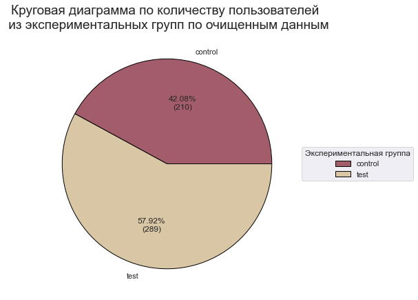

```python
group_pie_filtered = df_filtered.groupby('ab_group').agg({'user_id':'nunique'})\
.rename(columns={'user_id':'count_users'}).reset_index()

def my_fmt(x):
    return '{:.2f}%\n({:.0f})'.format(x, total_filterd*x/100)
total_filterd = group_pie_filtered['count_users'].sum()

plt.figure(figsize=(7,7))
plt.title('Круговая диаграмма по количеству пользователей \n из экспериментальных групп по очищенным данным', size = 19)
plt.pie(group_pie_filtered['count_users'], autopct = my_fmt, labels = group_pie_filtered['ab_group'],
        wedgeprops={'edgecolor': 'black'}, colors=colors[2:])
plt.legend(title = 'Экспериментальная группа',
          loc = 'center left',
             bbox_to_anchor=(1, 0, 0.5, 1))
plt.show()
```

Как видим, удаление аномальных пользователей практически не отразилось на соотношении количества пользователей в контрольной и тестовой группе. Теперь в тесте участвуют 289 (или 57.92% пользователей) тестовой группы и 210 (или 42.08%) пользователей из контрольной группы.

Точно также подготовим наши данные для визуализации кумулятивных метрик, как и в случае визуализации по "сырым данным".

```python
datesGroups_filtered = df_filtered[['date', 'ab_group']].drop_duplicates()
```

```python
cumulativeData_filtered = datesGroups_filtered.apply(lambda x: df_filtered[np.logical_and(df_filtered['date'] <= x['date'],
                                                                    df_filtered['ab_group'] == x['ab_group'])]\
                                    .agg({'date':'max', 'ab_group':'max',
                                         'user_id':pd.Series.nunique, 'price':'sum'}), axis=1)\
                                    .sort_values(by=['date', 'ab_group'])
cumulativeData_filtered.rename(columns={'user_id':'buyers', 'price':'revenue'}, inplace=True)
```

```python
cumulativeRevenueA_filtered = cumulativeData_filtered[cumulativeData_filtered['ab_group'] == 'control'][['date', 'revenue', 'buyers']]
cumulativeRevenueB_filtered = cumulativeData_filtered[cumulativeData_filtered['ab_group'] == 'test'][['date', 'revenue', 'buyers']]
```

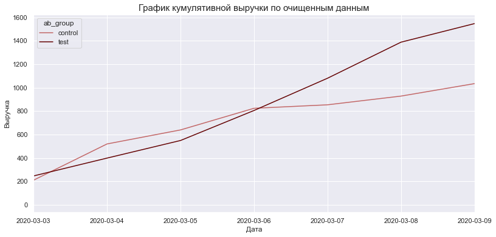

```python
plt.figure(figsize = (13,6))
plt.title('График кумулятивной выручки по очищенным данным',size=15)
sns.lineplot(data=cumulativeData_filtered, x='date', y='revenue', hue='ab_group', palette=[colors[1], colors[0]])
plt.xlabel('Дата', size=12)
plt.ylabel('Выручка', size=12)
plt.xticks(rotation=0)
plt.xlim(np.datetime64('2020-03-03 00:00:00'), np.datetime64('2020-03-09 00:00:00'))
plt.show()
```

Видим, что после удаления выбросов график кумулятивной выручки стал более сглаженным и плавным. Кумулятивная выручка по тестовой группе растет более стремительно, чем по контрольной и в середине теста обгоняет ее.

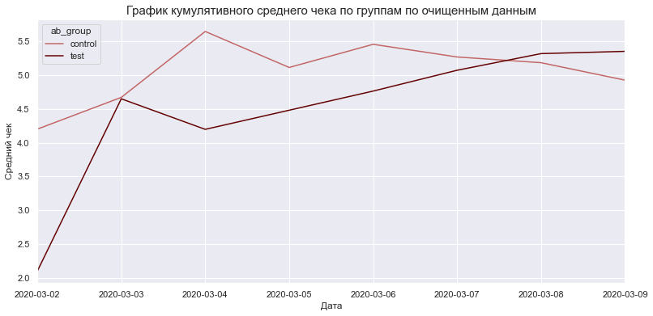

```python
plt.figure(figsize=(13,6))
plt.title('График кумулятивного среднего чека по группам по очищенным данным',size=15)
sns.lineplot(data=cumulativeData, x='date',
             y=cumulativeData_filtered['revenue']/cumulativeData_filtered['buyers'],
             hue='ab_group', palette=[colors[1], colors[0]])
plt.xlabel('Дата', size=12)
plt.ylabel('Cредний чек', size=12)
plt.xlim(np.datetime64('2020-03-02 00:00:00'), np.datetime64('2020-03-09 00:00:00'))
plt.xticks(rotation=0)
plt.show()
```

Тем не менее по графику кумулятивного среднего чека мы видим, что после удаления выбросов тестовая группа показала результаты хуже, чем контрольная. И только в конце периода начала "вырываться вперед".

```python
mergedCumulativeRevenue_filtered = cumulativeRevenueA_filtered.merge(cumulativeRevenueB_filtered,
                                                                     left_on='date', right_on='date',
                                                                       how='left', suffixes=['A', 'B'])
```

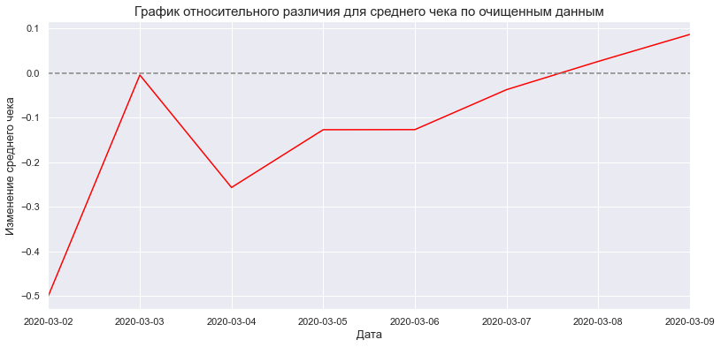

```python
#Построим график относительного различия для среднего чека
plt.figure(figsize=(13, 6))
plt.title('График относительного различия для среднего чека по очищенным данным', size=15)
sns.lineplot(data=mergedCumulativeRevenue_filtered,
             x=mergedCumulativeRevenue_filtered['date'],
             y=(mergedCumulativeRevenue_filtered['revenueB']/mergedCumulativeRevenue_filtered['buyersB'])
             /(mergedCumulativeRevenue_filtered['revenueA']/mergedCumulativeRevenue_filtered['buyersA'])-1,
             color='red')
plt.xticks(rotation=0)
plt.xlabel('Дата', size=13)
plt.ylabel('Изменение среднего чека', size=13)
plt.axhline(y=0, color='grey', linestyle='--')
plt.xlim(np.datetime64('2020-03-02 00:00:00'), np.datetime64('2020-03-09 00:00:00'))
plt.show()
```

Интересный паттерн - при удалении 12.7% выбросов (12 пользователей) мы получили в результате, что средний чек в контрольной группе выше среднего чека в тестовой. В целом, нас это не должно сильно смущать, поскольку в ТЗ написано, что к тестовой группе было применено дополнительное воздействие, которое должно было стимулировать более частые платежи. Средний чек у нас может быть меньше в тестовой группе при общем росте выручки потому что пользователи совершали больше покупок, но на меньшую сумму, а суммарная выручка при этом могла быть выше, чем в контрольной группе.

## Тестирование гипотез на очищенных данных

Разделим наши отфильтрованные данные на 2 выборки - контрольную и тестовую для дальнейшего тестирования гипотез.

```python
control_filtered = df_filtered[df_filtered['ab_group']=='control']['price']
test_filtered = df_filtered[df_filtered['ab_group']=='test']['price']
```

Построим Q-Q плот выборок для визуального определения - является ли распределение нормальным в наших выборках.

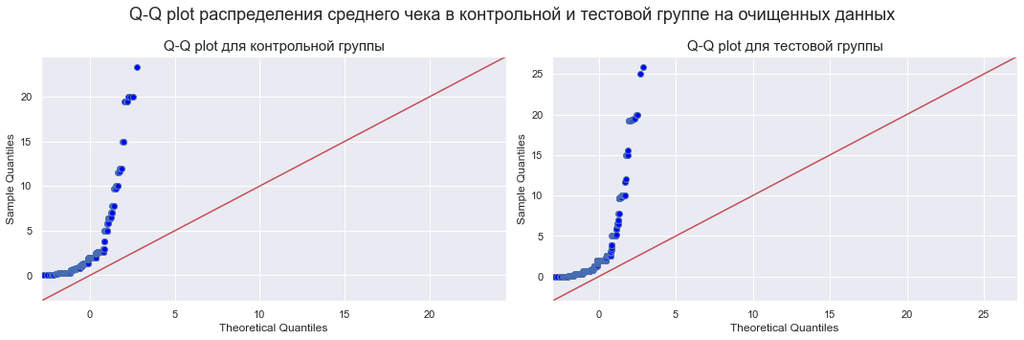

```python
fig, axs = plt.subplots(1,2, figsize=(15,5))
plt.suptitle('Q-Q plot распределения среднего чека в контрольной и тестовой группе на очищенных данных', size=18)

sm.qqplot(control_filtered, line='45', ax=axs[0])
axs[0].set_title('Q-Q plot для контрольной группы', size=15)

sm.qqplot(test_filtered, line='45', ax=axs[1])
axs[1].set_title('Q-Q plot для тестовой группы', size=15)

plt.tight_layout(pad=1)
plt.show()
```

После удаления выбросов распределение осталось таким же -отличным от нормального. Проверим данный факт дополнительно, используя тест Шапиро-Уилка.

Сформулируем нулевую и альтернативную гипотезы: **Н0** - выборка среднего чека в экспериментальной группе распределена нормально, **Н1** - распределение среднего чека в выборке отличается от нормального, **alpha** - критический уровень статистической значимости примем равным 5%

```python
alpha = 0.05
shapiro_control = shapiro(control_filtered)
print('**Результат по контрольной группе:**')
print(shapiro_control)
if shapiro_control.pvalue < alpha:
    print('Отвергаем нулевую гипотезу, распределение отлично от нормального')
else:
     print('Не отвергаем нулевую гипотезу, данные распределены нормально')

shapiro_test = shapiro(test_filtered)
print()
print('**Результат по тестовой группе:**')
print(shapiro_test)
if shapiro_test.pvalue < alpha:
    print('Отвергаем нулевую гипотезу, распределение отлично от нормального')
else:
     print('Не отвергаем нулевую гипотезу, данные распределены нормально')
```

```
**Результат по контрольной группе:**
ShapiroResult(statistic=0.6535568833351135, pvalue=4.186453084682426e-26)
Отвергаем нулевую гипотезу, распределение отлично от нормального

**Результат по тестовой группе:**
ShapiroResult(statistic=0.6317963600158691, pvalue=3.680320292032563e-32)
Отвергаем нулевую гипотезу, распределение отлично от нормального
```

Нулевая гипотеза отверглась - распределение отлично от нормального, а значит мы будем использовать непараметрический критерий Манна-Уитни для проверки гипотезы о наличии значимых различий в среднем чеке между экспериментальными группами.

Сформулируем нулевую и альтернативную гипотезы: **Н0** - значимые различия в среднем чеке в контрольной и тестовой группе отсутствуют, **Н1** - существуют значимые различия в среднем чеке в контрольной и тестовой группе, **alpha** - критический уровень статистической значимости примем равным 5%

```python
print('p-value критерия Манна-Уитни: {0:.3f}'.format(stats.mannwhitneyu(control_filtered, test_filtered,
                                                                        alternative='two-sided')[1]))
alpha=0.05
if stats.mannwhitneyu(control_filtered, test_filtered, alternative='two-sided')[1] < alpha:
    print('Отвергаем нулевую гипотезу, существуют значимые различия в среднем чеке в экспериментальных группах')
else:
    print('Не удалось отвергнуть нулевую гипотезу, значимые различия в среднем чеке в экспериментальных группах отсутствуют')
print('Относительные различия в среднем чеке между группами: {0:.3f}'.format(test_filtered.mean()/control_filtered.mean()-1))
```

```
p-value критерия Манна-Уитни: 0.169
Не удалось отвергнуть нулевую гипотезу, значимые различия в среднем чеке в экспериментальных группах отсутствуют
Относительные различия в среднем чеке между группами: -0.012
```

Теперь проведем проверку гипотез по средней выручке на одного пользователя. Агрегируем наши данные по уникальным пользователям на очищенных данных и найдем их суммарную выручку и количество покупок.

```python
orders_data_filtered = df_filtered.groupby('user_id').agg({'user_id':'count', 'price':'sum'})\
.rename(columns={'user_id':'count_orders', 'price':'revenue'}).reset_index()
id_group_filtered = df_filtered[['user_id', 'ab_group']].drop_duplicates()
orders_data_filtered = orders_data_filtered.merge(id_group_filtered, on='user_id', how='inner')
```

Разделим данные на 2 выборки по выручке - контрольную и тестовую.

```python
control_filt_revenue = orders_data_filtered[orders_data_filtered['ab_group'] == 'control']['revenue']
test_filt_revenue = orders_data_filtered[orders_data_filtered['ab_group'] == 'test']['revenue']
```

Построим Q-Q плоты для визуализации распределения.

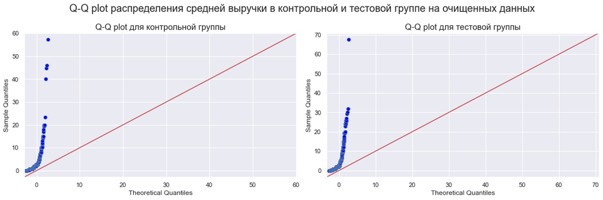

```python
fig, axs = plt.subplots(1,2, figsize=(15,5))
plt.suptitle('Q-Q plot распределения средней выручки в контрольной и тестовой группе на очищенных данных', size=18)

sm.qqplot(control_filt_revenue, line='45', ax=axs[0])
axs[0].set_title('Q-Q plot для контрольной группы', size=15)

sm.qqplot(test_filt_revenue, line='45', ax=axs[1])
axs[1].set_title('Q-Q plot для тестовой группы', size=15)

plt.tight_layout(pad=1)
plt.show()
```

Из графиков видим, что распределение отличается от нормального. Проведем дополнительно для подтверждения нашего предположения тест Шапиро-Уилка.

Сформулируем нулевую и альтернативную гипотезы: **Н0** - средняя выручка в экспериментальной группе распределена нормально, **Н1** - распределение средней выручки в выборке отличается от нормального, **alpha** - критический уровень статистической значимости примем равным 5%

```python
alpha = 0.05
shapiro_control = shapiro(control_filt_revenue)
print('**Результат по контрольной группе:**')
print(shapiro_control)
if shapiro_control.pvalue < alpha:
    print('Отвергаем нулевую гипотезу, распределение отлично от нормального')
else:
     print('Не отвергаем нулевую гипотезу, данные распределены нормально')

shapiro_test = shapiro(test_filt_revenue)
print()
print('**Результат по тестовой группе:**')
print(shapiro_test)
if shapiro_test.pvalue < alpha:
    print('Отвергаем нулевую гипотезу, распределение отлично от нормального')
else:
     print('Не отвергаем нулевую гипотезу, данные распределены нормально')
```

```
**Результат по контрольной группе:**
ShapiroResult(statistic=0.5502908229827881, pvalue=5.663228020960575e-23)
Отвергаем нулевую гипотезу, распределение отлично от нормального

**Результат по тестовой группе:**
ShapiroResult(statistic=0.6325922012329102, pvalue=1.85405840503436e-24)
Отвергаем нулевую гипотезу, распределение отлично от нормального
```

Нулевые гипотезы отвергаются, распределение в выборках по средней выручке на пользователя отлично от нормального. Значит используем тест Манна-Уитни

Сформулируем нулевую и альтернативную гипотезы: **Н0** - значимые различия в средней выручке в контрольной и тестовой группе отсутствуют, **Н1** - существуют значимые различия в средней выручке в контрольной и тестовой группе, **alpha** - критический уровень статистической значимости примем равным 5%

```python
print('p-value критерия Манна-Уитни: {0:.3f}'.format(stats.mannwhitneyu(control_filt_revenue, test_filt_revenue,
                                                                        alternative='two-sided')[1]))
alpha=0.05
if stats.mannwhitneyu(control_filt_revenue, test_filt_revenue, alternative='two-sided')[1] < alpha:
    print('Отвергаем нулевую гипотезу, существуют значимые различия в средней выручке в экспериментальных группах')
else:
    print('Не удалось отвергнуть нулевую гипотезу, значимые различия в средней выручке в экспериментальных группах отсутствуют')
print('Относительные различия в средней выручке между группами: {0:.3f}'\
      .format(test_filt_revenue.mean()/control_filt_revenue.mean()-1))
print('Относительные различия в суммарной выручке между группами: {0:.3f}'\
      .format(test_filt_revenue.sum()/control_filt_revenue.sum()-1))
```

```
p-value критерия Манна-Уитни: 0.318
Не удалось отвергнуть нулевую гипотезу, значимые различия в средней выручке в экспериментальных группах отсутствуют
Относительные различия в средней выручке между группами: 0.087
Относительные различия в суммарной выручке между группами: 0.495
```

В результате тестирования гипотезы о наличии значимых различий в средней выручке с использованием теста Манна-Уитни получили, что значимые различия в средней выручке в экспериментальных группах отсутствуют (p-value=0.318). При этом относительные различия в средней выручке составляют 8.7%, т.е. тестовая группа показала лучший результат. Если посмотреть на относительные различия суммарной выручки - разница между сегментами составляет почти 50% с выигрышем тестовой группы.

## Выводы по всему тесту

- В датасете присутствуют 2 группы A/B теста - контрольная и тестовая, даны id пользователей, цена совершенной покупки по каждому пользователю и даты совершения покупки.
- Всего в данных 1139 строк и 4 столбца.
- Столбец date перевели в формат даты, а также понизили разрядность типов данных и таким образом оптимизировали работу кода.
- Дубликаты отстутствуют.
- В датасете присутствуют пользователи, попавшие и в группу A, и в группу B. Таких пользователей 31 во всем датасете. Мы их удалили из наших данных, поскольку они будут искажать проведение А/Б теста.
- Мы располагаем данными за недельный период: 02.03.2020 -09.03.2020. По распределению видим, что у нас полные данные за рассматриваемый период времени. Но период проведения А/Б теста совпадает с праздником - 8 марта, что в целом может привести к искажению результатов теста.
- Есть небольшой перекос в количестве пользователей, участвующих в тесте - количество пользователей в контрольной группе - 212 (41.49%), количество пользователей в тестовой группе - 299 (58.51%). В ТЗ звучит информация, что всего в тесте участвовало ровно по 1000 пользователей в каждой группе. У нас не набралось такого количества пользователей - общее количество пользователей, участвующих в А/Б тесте по нашим расчетам - 511.

**Анализ куммулятивной выручки и среднего чека по группам на сырых данных**

**Анализ выбросов**

- По количеству заказов в контрольной и тестовой группе наблюдаются выбросы. Больше всего пользователей совершили до 5 покупок. Значения выше 16 покупок можно назвать выбросами.
- Больше всего пользователей совершили покупки на сумму до 11 у.е. Значения цены свыше 25 у.е. являются выбросами.

**Тестирование гипотез на сырых данных**

- Разделили наши данные на 2 выборки - по контрольной и тестовой группе.
- Построили графики для визуального анализа распределения в наших выборках. В результате увидили, что распределение далеко от нормального в контрольной и тестовой выборке
- Дополнительно проверили наше утверждение, используя тест Шапиро-Уилка. После проведения теста получили что гипотеза H0 отвергается (Н0 - выборка среднего чека в экспериментальной группе распределена нормально), поэтому далее использовали непараметрический критерий Манна-Уитни для тестирования гипотезы о наличии значимого различия в среднем чеке контрольной и тестовой группах.
- По "сырым" данным с выбросами получили, что нулевая гипотеза отвергается, существуют значимые различия среднего чека в экспериментальных группах. Средний чек тестовой группы значительно выше среднего чека контрольной группы, о чем свидетельствуют расчеты относительных различий в среднем чеке между группами - разница составляет 11.6%
- Провели тестирование гипотезы о наличии значимых различий в средней выручке на пользователя по сырым данным. Разделили данные на 2 выборки средней выручки - контрольную и тестовую. Построили Q-Q плоты для визуализации распределения. Распределение по выборкам отлично от нормального, проверили дополнительно это утверждение проведя тест Шапиро-Уилка. Гипотеза о том, что выборка распределена нормально отверглась в случае тестовой и контрольной группы, соответственно использовали Тест Манна-Уитни для проверки гипотезы о том, является ли разница в средней выручке между группами статистически значимой.
- Нам не удалось отвергнуть нулевую гипотезу, значимые различия в средней выручке в экспериментальных группах отсутствуют. При этом при расчете относительных различий в средней выручке между группами получили, что тестовая группа показала результаты лучше, чем контрольная - выручка выше на 34.6%. При этом разница между сегментами в суммарной выручке составляет 89.8%

**Анализ куммулятивной выручки и среднего чека по группам на очищенных данных**

**Тестирование гипотез на очищенных данных**

По результатам теста было принято решение остановить тест, оставить контрольную вариацию. Значимых различий среднего чека и средней выручки между двумя группами на очищенных данных не наблюдается. К тому же, есть вопросы по корректности проведения теста: - Даты проведения теста совпали с праздником 8 марта, что может искажать результаты - Мы не набрали целевое количество пользователей, как было указано в ТЗ (по 1000 пользователей в каждой группе) - Количество пользователей несбалансировано по группам